# WindCurves: A Tool to Fit Wind Turbine Power Curves

Neeraj Bokde (neerajdhanraj@gmail.com) and Andres Feijoo (afeijoo@uvigo.es)

2022-04-30

## Introduction:

This is a Vignettes of R package, `WindCurves`. The package `WindCurves` is a tool used to fit the wind turbine power curves. It can be useful for researchers, data analysts/scientist, practitioners, statistians and students working on wind turbine power curves. The salient features of `WindCurves` package are:

- Fit the power curve with Weibull CDF, Logistic [1] and user defined techniques.
- Comparison and visualization of the performance of curve fitting techniques.
- Utilise as a Testbench to compare performace of user defined curve fitting techniques with user defined error measures.
- Availability of Dataset [2] on the power curves of wind turbine from four major manufacturers: Siemens, Vestas, REpower and Nordex.
- Feature to extract/capture Speed Vs Power discrete points from power curve image

## Instructions to Use:

- A power curve can be fitted with the `WindCurves` package from a discrete samples of wind turbine power curves provided by turbine manufacurers as:

```r
library(WindCurves)
data(pcurves)
s <- pcurves$Speed
p <- pcurves$`Nordex N90`
da <- data.frame(s,p)
x <- fitcurve(da)
```

```
#>    Weibull CDF model
#>    -----------------
#>    P = 1 - exp[-(S/C)^k]
#>    where P -> Power and S -> Speed
#>
#>     Shape (k) = 4.242446
#>     Scale (C) = 9.564993
#>    ===================================
#>
#>    Logistic Function model
#>    -----------------------
#>    P = phi1/(1+exp((phi2-S)/phi3))
#>    where P -> Power and S -> Speed
#>
#>     phi 1 = 2318.242
#>     phi 2 = 8.658611
#>     phi 3 = 1.366054
#>    ===================================
```

```r
x
```

```
#> $Speed
#>  [1]  1  2  3  4  5  6  7  8  9 10 11 12 13 14 15 16 17 18 19 20 21 22 23 24 25
#>
#> $Power
#>  [1]    0    0    0   35  175  352  580  870 1237 1623 2012 2230 2300 2300 2300
#> [16] 2300 2300 2300 2300 2300 2300 2300 2300 2300 2300
#>
#> $`Weibull CDF`
#>  [1]    0.0000    0.0000    0.0000   90.3871  175.0000  327.5161  563.9085
#>  [8]  882.3965 1253.7489 1623.0000 1929.1254 2134.6685 2242.6251 2285.2438
#> [15] 2297.3355 2299.6816 2299.9764 2299.9990 2300.0000 2300.0000 2300.0000
#> [22] 2300.0000 2300.0000 2300.0000 2300.0000
#>
#> $`Logistic Function`
#>  [1]    0.00000    0.00000    0.00000   74.12834  148.99362  289.70749
#>  [7]  530.79747  884.98926 1303.20935 1686.50694 1964.36660 2133.40769
#> [13] 2225.51217 2272.70001 2296.11395 2307.54706 2313.08621 2315.75963
#> [19] 2317.04756 2317.66748 2317.96573 2318.10919 2318.17820 2318.21138
#> [25] 2318.22734
#>
#> attr(,"class")
#> [1] "fitcurve"
#> attr(,"row.names")
#>  [1]  1  2  3  4  5  6  7  8  9 10 11 12 13 14 15 16 17 18 19 20 21 22 23 24 25
```

```r
validate.curve(x)
```

```
#>   Metrics Weibull CDF Logistic Function
#> 1    RMSE  30.8761687        38.8753476
#> 2     MAE  15.1381094        29.3213876
#> 3    MAPE   3.9292946         5.9183675
#> 4      R2   0.9989322         0.9983073
#> 5     COR   0.9995413         0.9991591
```

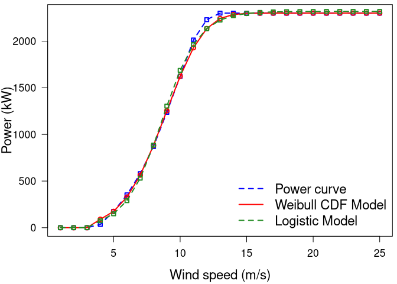

```r
plot(x)
```

- User can utilize `WindCurves` package as a testbench so that a new curve fitting technique can be compared with above mentioned existing environment.
- - The user defined function (similar to `random()`) should be saved in .R format and it should return the fitted values in terms of “Power values”. The `random()` function used in this example is stored as .R file with `dump()` function and made available in the `WindCurves` package and written as:

```r
random <- function(x)
{
  data_y <- sort(sample(1:1500, size = 25, replace = TRUE))
  d <- data.frame(data_y)
  return(d)
}
dump("random")
rm(random)
```

- A `random()` function is attached in the comparison the parameters `MethodPath` and `MethodName` as shown below, where `MethodPath` is a location of the function proposed by the user and `MethodName` is a name given to the function.

```r
library(WindCurves)
data(pcurves)
s <- pcurves$Speed
p <- pcurves$`Nordex N90`
da <- data.frame(s,p)
x <- fitcurve(data = da, MethodPath = "source('dumpdata.R')", MethodName = "Random values")
```

```
#>    Weibull CDF model
#>    -----------------
#>    P = 1 - exp[-(S/C)^k]
#>    where P -> Power and S -> Speed
#>
#>     Shape (k) = 4.242446
#>     Scale (C) = 9.564993
#>    ===================================
#>
#>    Logistic Function model
#>    -----------------------
#>    P = phi1/(1+exp((phi2-S)/phi3))
#>    where P -> Power and S -> Speed
#>
#>     phi 1 = 2318.242
#>     phi 2 = 8.658611
#>     phi 3 = 1.366054
#>    ===================================
```

```r
## The user can specify .R files from other locations as:
# x <- fitcurve(data = da, MethodPath = "source('~/WindCurves/R/random.R')", MethodName = "Random values")
validate.curve(x)
```

```
#>   Metrics Weibull CDF Logistic Function Random values
#> 1    RMSE  30.8761687        38.8753476  1113.3246966
#> 2     MAE  15.1381094        29.3213876   944.6000000
#> 3    MAPE   3.9292946         5.9183675   153.4750152
#> 4      R2   0.9989322         0.9983073    -0.3882757
#> 5     COR   0.9995413         0.9991591     0.8677849
```

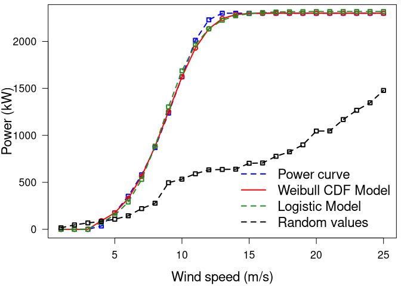

```r
plot(x)
```

- Also, `WindCurves` allows user to add more error measures with `validate.curve()` function as explained below:

Consider `error()` is a function which uses two vectors as input and returns a error value with a specific error measure, such as RMSE or MAPE as shown below:

```r
# PCV as an error metric
error <- function(a,b)
{
d <- (var(a) - var(b)) * 100/ var(a)
d <- as.numeric(d)
return(d)
}
dump("error")
rm(error)
```

The effect of this function can be seen in the results obtained with `Validate.curve()` function as:

```r
library(WindCurves)
data(pcurves)
s <- pcurves$Speed
p <- pcurves$`Nordex N90`
da <- data.frame(s,p)
x <- fitcurve(da)
```

```
#>    Weibull CDF model
#>    -----------------
#>    P = 1 - exp[-(S/C)^k]
#>    where P -> Power and S -> Speed
#>
#>     Shape (k) = 4.242446
#>     Scale (C) = 9.564993
#>    ===================================
#>
#>    Logistic Function model
#>    -----------------------
#>    P = phi1/(1+exp((phi2-S)/phi3))
#>    where P -> Power and S -> Speed
#>
#>     phi 1 = 2318.242
#>     phi 2 = 8.658611
#>     phi 3 = 1.366054
#>    ===================================
```

```r
validate.curve(x = x, MethodPath = "source('dumpdata.R')", MethodName = "New Error")
```

```
#>     Metrics Weibull CDF Logistic Function
#> 1      RMSE  30.8761687        38.8753476
#> 2       MAE  15.1381094        29.3213876
#> 3      MAPE   3.9292946         5.9183675
#> 4        R2   0.9989322         0.9983073
#> 5       COR   0.9995413         0.9991591
#> 6 New Error  -1.8141636         0.4127417
```

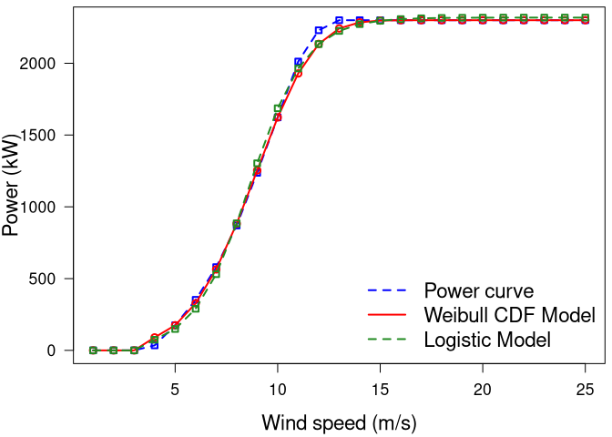

```r
plot(x)
```

Similarly, user can compare various techniques used for wind turbine power curve fitting.

- Dataset [2] on the power curves of wind turbine from four major manufacturers: Siemens, Vestas, REpower and Nordex. These datsset represent wind turbine power output in ‘kW’ against wind speed in ‘metres per second’ as shown below:

```r
data(pcurves)
pcurves
```

```
#>    Speed Vestad V80 Vestad V164 Siemens 82 Siemens 107 Repower 82 Nordex N90
#> 1      1          0           0          0           0          0          0
#> 2      2          0           0          0           0          0          0
#> 3      3          0           0          0           0          0          0
#> 4      4          2         101         42          80         64         35
#> 5      5         97         461        136         238        159        175
#> 6      6        255         902        276         474        314        352
#> 7      7        459        1595        470         802        511        580
#> 8      8        726        2513        727        1234        767        870
#> 9      9       1004        3737       1043        1773       1096       1237
#> 10    10       1330        4988       1394        2379       1439       1623
#> 11    11       1627        5987       1738        2948       1700       2012
#> 12    12       1772        6698       2015        3334       1912       2230
#> 13    13       1797        6984       2183        3515       2000       2300
#> 14    14       1802        6985       2260        3577       2040       2300
#> 15    15       1802        6995       2288        3594       2050       2300
#> 16    16       1802        6995       2297        3599       2050       2300
#> 17    17       1802        6995       2299        3600       2050       2300
#> 18    18       1802        6995       2300        3600       2050       2300
#> 19    19       1802        6995       2300        3600       2050       2300
#> 20    20       1802        6995       2300        3600       2050       2300
#> 21    21       1802        6995       2300        3600       2050       2300
#> 22    22       1802        6995       2300        3600       2050       2300
#> 23    23       1802        6995       2300        3600       2050       2300
#> 24    24       1800        6995       2300        3600       2050       2300
#> 25    25       1800        6995       2300        3600       2050       2300
```

- Further, `WindCurves` package provides feature to extract/capture Speed Vs Power discrete points from power curve image. This can be achieved with the following simple instruction:

```r
#img2points("image.jpeg")
```

where, `image.jpeg` is the name of power curve image from which discrete points are to extracted. The procedure of extraction is as follows:

- With the command `img2points("image.jpeg")`, an image will get appeared in the Viewer.
- Click on leftmost point of the X-axis of the curve image and assign the respective appropriate value.
- click on rightmost point on X-axix, downmost point of Y-axis and topmost point of Y-axis, and assign their values, respectively.
- click of the points on the curve image. By default, 15 points can be captured from the curve image, but user can set the desired number of points with `n` parameter in `img2points()` function.
- This function returns a data.frame with two columns, i.e., wind speed and wind power, which can be used as input data for `fitcurve()` function.

## References

> [1] D. Villanueva and A. E. Feij´oo, “Reformulation of parameters of the logistic function applied to power curves of wind turbines,” Electric Power Systems Research, vol. 137, pp. 51–58, 2016.([via](https://www.sciencedirect.com/science/article/pii/S0378779616300992))

> [2] Iain Staffell, “Wind turbine power curves, 2012” ([via](https://goo.gl/tD2JW6))